# Study of US Craft Beer and Breweries

David Stroud, Cory Thigpen, Korey MacVittie, and Stacy Conant

February 2018

## Introduction and Overview

In this report, we explore datasets for various `beers` and the `breweries` that produce them in the US. The steps and procedures taken for this analysis are detailed below.

The initial data provided were in two separate datasets, one each for beers and breweries, which were combined into a single dataset.

### Repository Structure

Our Git repository {https://github.com/davestroud/BeerStudy} is relatively unstructured, with the following pertinent files contained within:

- [`README.md`](https://github.com/davestroud/BeerStudy/blob/master/README.md) : This is the base page for the repository, containing an introduction as well as our codebook for how we coded variable names throughout the datasets.
- [`BottomsUp_DS.Rmd`](https://github.com/davestroud/BeerStudy/blob/master/BottomsUp_DS.Rmd) : This is the primary file for the analysis, and is the file you are currently reading. It contains all the relevant R code, graphics, and analysis for the project; also included are specific .docx, .html, and .pdf knitted versions of this file.
- [`Beers.csv`](https://github.com/davestroud/BeerStudy/blob/master/Beers.csv) and [`Breweries.csv`](https://github.com/davestroud/BeerStudy/blob/master/Breweries.csv), were provided and are the original datasets from which our merged dataset is produced.

### Reproduction of Analysis

It would be suggested to start with the `README.md` file to acquaint yourself with our nomenclature. Clone or otherwise download this repository, then run the `BottomsUp_DS.Rmd` file.

## Analysis

We begin by setting `knitr` options, loading various libraries we will need for our analysis, and reading in our data.

```r
# Read in beer and breweries data set using _csv for more tidy output
Beers <- read_csv('Beers.csv', col_types = cols())
Breweries <- read_csv('Breweries.csv', col_types = cols())
```

The field `Brewery_id` in `Beers.csv` and `Brew_ID` in `Breweries.csv` are the same data, but do not share a name. We remedy this by renaming the column in `Beers.csv`.

## Research Questions

We can now address the research questions put forth on the dataset.

### 1. How many breweries are present in each state?

We answer this question by retrieving the value of `State` from the `Breweries` data.

```r
BrewPerState <-table(Breweries$State)
BrewPerState
```

```
##
## AK AL AR AZ CA CO CT DC DE FL GA HI IA ID IL IN KS KY LA MA MD ME MI MN MO
##  7  3  2 11 39 47  8  1  2 15  7  4  5  5 18 22  3  4  5 23  7  9 32 12  9
## MS MT NC ND NE NH NJ NM NV NY OH OK OR PA RI SC SD TN TX UT VA VT WA WI WV
##  2  9 19  1  5  3  3  4  2 16 15  6 29 25  5  4  1  3 28  4 16 10 23 20  1
## WY
##  4
```

```r
# Renamed Brewery_id to Brew_ID to satisfy merging requirement
Beers <- rename(Beers, Brew_ID = Brewery_id)
```

### 2. Merge beer data with the breweries data. Print the first 6 observations and the last six observations to check the merged file.

As part of our analysis, we ensured that duplicate data within each dataset shared the same variable name in both sets. We can now merge them into a single dataset, using `full_join`.

```r
BrewPub <- full_join(Beers, Breweries, by="Brew_ID")
```

To retrieve the first and last six observations from the combined data, we run `head` and `tail` on `BrewPub`, our combined dataset.

```r
kable(BrewPub %>% head())
```

| Name.x | Beer_ID | ABV | IBU | Brew_ID | Style | Ounces | Name.y | City | State |
| --- | --- | --- | --- | --- | --- | --- | --- | --- | --- |
| Pub Beer | 1436 | 0.050 | NA | 409 | American Pale Lager | 12 | 10 Barrel Brewing Company | Bend | OR |
| Devil’s Cup | 2265 | 0.066 | NA | 178 | American Pale Ale (APA) | 12 | 18th Street Brewery | Gary | IN |
| Rise of the Phoenix | 2264 | 0.071 | NA | 178 | American IPA | 12 | 18th Street Brewery | Gary | IN |
| Sinister | 2263 | 0.090 | NA | 178 | American Double / Imperial IPA | 12 | 18th Street Brewery | Gary | IN |
| Sex and Candy | 2262 | 0.075 | NA | 178 | American IPA | 12 | 18th Street Brewery | Gary | IN |
| Black Exodus | 2261 | 0.077 | NA | 178 | Oatmeal Stout | 12 | 18th Street Brewery | Gary | IN |

```r
kable(BrewPub %>% tail())
```

| Name.x | Beer_ID | ABV | IBU | Brew_ID | Style | Ounces | Name.y | City | State |
| --- | --- | --- | --- | --- | --- | --- | --- | --- | --- |
| Rocky Mountain Oyster Stout | 1035 | 0.075 | NA | 425 | American Stout | 12 | Wynkoop Brewing Company | Denver | CO |
| Belgorado | 928 | 0.067 | 45 | 425 | Belgian IPA | 12 | Wynkoop Brewing Company | Denver | CO |
| Rail Yard Ale | 807 | 0.052 | NA | 425 | American Amber / Red Ale | 12 | Wynkoop Brewing Company | Denver | CO |
| B3K Black Lager | 620 | 0.055 | NA | 425 | Schwarzbier | 12 | Wynkoop Brewing Company | Denver | CO |
| Silverback Pale Ale | 145 | 0.055 | 40 | 425 | American Pale Ale (APA) | 12 | Wynkoop Brewing Company | Denver | CO |
| Rail Yard Ale (2009) | 84 | 0.052 | NA | 425 | American Amber / Red Ale | 12 | Wynkoop Brewing Company | Denver | CO |

### 3. Report the number of NA’s in each column.

To do this, we use a function (which returns `true` if a given value is NA, `false` otherwise, using `is.na`) and `sapply` to determine the number of missing values for each column within `BrewPub`.

```r
MissingValues <- sapply(BrewPub, function(x)sum(is.na(x)))
# Used kable library to make document more presentable
MissingValues %>%
  kable("html") %>%
  kable_styling()
```

|  | x |
| --- | --- |
| Name.x | 0 |
| Beer_ID | 0 |
| ABV | 62 |
| IBU | 1005 |
| Brew_ID | 0 |
| Style | 5 |
| Ounces | 0 |
| Name.y | 0 |
| City | 0 |
| State | 0 |

### 4. Compute the median alcohol content and international bitterness unit for each state. Plot a bar chart to compare.

We build two new datasets, `Bitter` and `FireWater`, from our `BrewPub` dataset, omitting NA values. We then group the relevant values by state, and summarise by the median of the relevant value.

```r
# 4. Compute the median alcohol content unit for each state.
Firewater <- BrewPub %>%
  na.omit() %>%
group_by(State) %>%
summarise(Median = median(ABV)) %>%
arrange(Median)
```

```r
# 4. a Compute the median international bitterness unit for each state.
Bitter <- BrewPub %>%
  na.omit() %>%
group_by(State) %>%
summarise(Median = median(IBU)) %>%
arrange(Median)
```

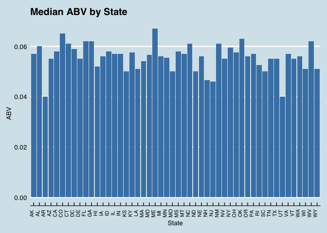

```r
# 4. b Plot a bar chart to compare ABV by state
library(ggthemes)
ggplot(data=Firewater, aes(x=State, y=Median)) +
  geom_bar(stat="identity", fill="steelblue")+
  theme_economist() +
  scale_color_economist()+
  theme(axis.text.x=element_text(size=rel(0.8), angle=90)) +
  ggtitle("Median ABV by State") +
  labs(x="State",y="ABV")
```

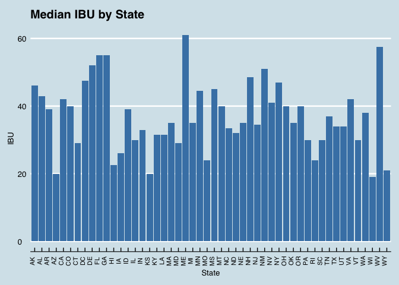

```r
# 4. c Plot a bar chart to compare IBU by state
ggplot(data=Bitter, aes(x=State, y=Median)) +
  geom_bar(stat="identity", fill="steelblue")+
  theme_economist() +
  scale_color_economist()+
  theme(axis.text.x=element_text(size=rel(0.8), angle=90))+
  ggtitle("Median IBU by State") +
  labs(x="State",y="IBU")
```

### 5. Which state has the maximum alcoholic (ABV) beer? Which state has the most bitter (IBU) beer?

We use `which.max` on our `BrewPub` dataset, seeking specifically the maximum value in the `ABV` and `IBU` columns.

From this, we identify Colorado as having the beer with the highest ABV, at `.128`; and we identify Oregon has having the beer with the highest IBU, at `138`.

```r
kable(BrewPub[which.max(BrewPub$ABV),])
```

| Name.x | Beer_ID | ABV | IBU | Brew_ID | Style | Ounces | Name.y | City | State |
| --- | --- | --- | --- | --- | --- | --- | --- | --- | --- |
| Lee Hill Series Vol. 5 - Belgian Style Quadrupel Ale | 2565 | 0.128 | NA | 52 | Quadrupel (Quad) | 19.2 | Upslope Brewing Company | Boulder | CO |

```r
kable(BrewPub[which.max(BrewPub$IBU),])
```

| Name.x | Beer_ID | ABV | IBU | Brew_ID | Style | Ounces | Name.y | City | State |
| --- | --- | --- | --- | --- | --- | --- | --- | --- | --- |
| Bitter Bitch Imperial IPA | 980 | 0.082 | 138 | 375 | American Double / Imperial IPA | 12 | Astoria Brewing Company | Astoria | OR |

### 6. Summary statistics for the ABV variable.

We do this by calling `summary` on the `ABV` column in our `BrewPub` dataset.

```r
BeerSummary <- (summary(BrewPub$ABV))
print(BeerSummary)
```

```
##    Min. 1st Qu.  Median    Mean 3rd Qu.    Max.    NA's
## 0.00100 0.05000 0.05600 0.05977 0.06700 0.12800      62
```

### 7. Is there an apparent relationship between the bitterness of the beer and its alcoholic content? Draw a scatter plot.

We utilize `ggplot` to plot a scatter plot of the data, using `IBU` and `ABV` as our variables.

Examination of this scatter plot and the regression line suggests that there is a positive, linear relationship between `IBU` and `ABV`.

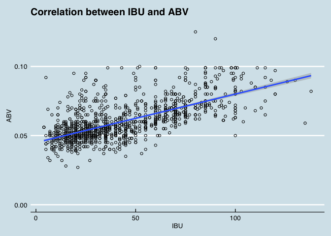

```r
# 7. Draw a scatter plot to compare relationship between beer
# bitterness and alcohol content
ggplot(BrewPub, aes(x=IBU, y= ABV)) +
  geom_point(shape=1) +
   geom_smooth(method=lm) + # add linear regression line
  theme_economist() +
  scale_color_economist()+
  theme(axis.text.x=element_text(size=rel(1.0)))+
ggtitle("Correlation between IBU and ABV ") +
  labs(x="IBU",y="ABV")
```

## Review and Conclusion

In this analysis, we examined data gleaned from two datasets regarding beers and breweries throughout the US. We examined the structure of this data, cleaned them, and combined them. We then performed various analyses, such as calculating median values for IBU and ABV by state, and determining which states had the beers with the highest ABV and IBU values. We finished by looking for a potential relationship between IBU and ABV, and found that there is evidence to suggest that a positive correlation exists between the two.